# Homework 4

Calvin Wong

10/1/2018

Graded: 4.4, 4.14, 4.24, 4.26, 4.34, 4.40, 4.48

1. What is the point estimate for the average height of active individuals? What about the median?

The point estimate for the average height of active individuals is 171.1. The median is 170.3.

2. What is the point estimate for the standard deviation of the heights of active individuals? What about the IQR?

The SD is 9.4 and IQR is (177.8 - 163.8) 14.

3. Is a person who is 1m 80cm (180 cm) tall considered unusually tall? And is a person who is 1m 55cm (155cm) considered unusually short? Explain your reasoning.

```r
Z180 <- (180 - 171.1)/9.4
Z155 <- (155 - 171.1)/9.4
print(c(Z180, Z155))
```

```
## [1]  0.9468085 -1.7127660
```

4. The researchers take another random sample of physically active individuals. Would you expect the mean and the standard deviation of this new sample to be the ones given above? Explain your reasoning.

No. Point estimates that are based on samples only approximate the population parameter, and they vary from one sample to another.

5. The sample means obtained are point estimates for the mean height of all active individuals, if the sample of individuals is equivalent to a simple random sample. What measure do we use to quantify the variability of such an estimate (Hint: recall that SD¯x = ! pn )? Compute this quantity using the data from the original sample under the condition that the data are a simple random sample.

We use the SE, which is 0.417 for this sample’s mean.

```r
SE <- 9.4/sqrt(507)
print(SE)
```

```
## [1] 0.4174687
```

4.14 Thanksgiving spending, Part I. The 2009 holiday retail season, which kicked on November 27, 2009 (the day after Thanksgiving), had been marked by somewhat lower self-reported consumer spending than was seen during the comparable period in 2008. To get an estimate of consumer spending, 436 randomly sampled American adults were surveyed. Daily consumer spending for the six-day period after Thanksgiving, spanning the Black Friday weekend and Cyber Monday, averaged $84.71. A 95% confidence interval based on this sample is ($80.31, $89.11). Determine whether the following statements are true or false, and explain your reasoning.

1. We are 95% confident that the average spending of these 436 American adults is between $80.31 and $89.11.

FALSE - The confidence interval looks at the population not just the sample size

2. This confidence interval is not valid since the distribution of spending in the sample is right skewed.

FALSE - The sample size is large enough.

3. 95% of random samples have a sample mean between $80.31 and $89.11.

FALSE - The sample mean is for the population not for randon samples.

4. We are 95% confident that the average spending of all American adults is between $80.31 and $89.11.

TRUE - The confidence interval looks at the population.

5. A 90% confidence interval would be narrower than the 95% confidence interval since we don’t need to be as sure about our estimate.

TRUE - A 90% confidence interval would be narrower because it captures less range of values than a 95% confidence interval.

6. In order to decrease the margin of error of a 95% confidence interval to a third of what it is now, we would need to use a sample 3 times larger.

FALSE - The sample size should be 9 times larger.

7. The margin of error is 4.4.

TRUE

```r
SE <- (89.11 - 84.71)/1.96
SE * 1.96
```

```
## [1] 4.4
```

1. Are conditions for inference satisfied?

The sample is random and 36 children would almost certainly make up less than 10% of a large city. The sample size is at least 30. Observing the data to check skew, we see that the skew is not very strong. I would say that the conditions for inference is satisfied.

2. Suppose you read online that children first count to 10 successfully when they are 32 months old, on average. Perform a hypothesis test to evaluate if these data provide convincing evidence that the average age at which gifted children fist count to 10 successfully is less than the general average of 32 months. Use a significance level of 0.10.

Since the pvalue is 0.034 and significance level is larger at 0.10, we reject H0 in favor of HA.

```r
n <- 36
sd <- 4.31
se <- sd/sqrt(n)
mean <- 32

z_score = (30.69 - mean)/se
print(paste("z_score is ", round(z_score, 3)))
```

```
## [1] "z_score is  -1.824"
```

```r
pnorm(q = 30.69, mean, se)
```

```
## [1] 0.0341013
```

3. Interpret the p-value in context of the hypothesis test and the data.

4. Calculate a 90% confidence interval for the average age at which gifted children first count to 10 successfully.

```r
n <- 36
sd <- 4.31
se <- sd/sqrt(n)
mean <- 30.69

print(c(mean - 1.64 * se, mean + 1.64 * se))
```

```
## [1] 29.51193 31.86807
```

5. Do your results from the hypothesis test and the confidence interval agree? Explain.

The results agree. The p-value instructs us to reject the null hypothesis that the average age is 32 months, and the confidence interval does not include 32 months.

1. Perform a hypothesis test to evaluate if these data provide convincing evidence that the average IQ of mothers of gifted children is different than the average IQ for the population at large, which is 100. Use a significance level of 0.10.
2. Calculate a 90% confidence interval for the average IQ of mothers of gifted children.
3. Do your results from the hypothesis test and the confidence interval agree? Explain.

4.34 CLT. Define the term “sampling distribution” of the mean, and describe how the shape, center, and spread of the sampling distribution of the mean change as sample size increases.

The Sampling Distribution of the Mean is the mean of the population from where the items are sampled. If the population distribution is normal, then the sampling distribution of the mean is likely to be normal for the samples of all sizes. The central limit theorem states that regardless of the shape of the parent population, the sampling distribution of the mean approaches a normal distribution as sample size increases.

4.40 CFLBs. A manufacturer of compact fluorescent light bulbs advertises that the distribution of the lifespans of these light bulbs is nearly normal with a mean of 9,000 hours and a standard deviation of 1,000 hours. (a) What is the probability that a randomly chosen light bulb lasts more than 10,500 hours?

6.68% that a randomly chosen light bulb lasts more than 10,500 hours

```r
1-pnorm(q=10500, mean=9000, sd=1000)
```

```
## [1] 0.0668072
```

2. Describe the distribution of the mean lifespan of 15 light bulbs.

3. What is the probability that the mean lifespan of 15 randomly chosen light bulbs is more than 10,500 hours?

The probability of this happening is really small, this value is close to 0.

```r
(1 - pnorm(q=10500, mean=9000, sd=258.20)) * 100000
```

```
## [1] 0.000313392
```

4. Sketch the two distributions (population and sampling) on the same scale.

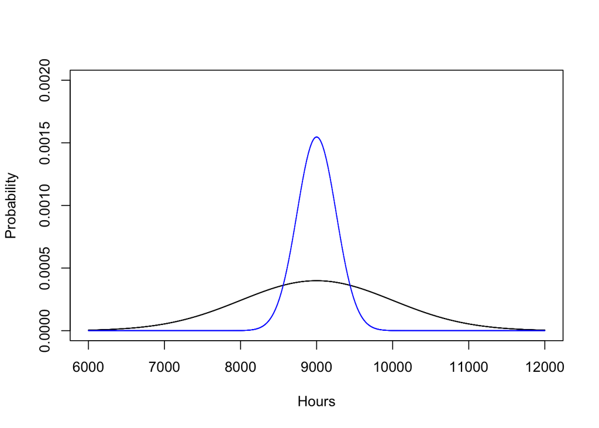

```r
s <- seq(6000,12000,0.01)
plot(s, dnorm(s,9000, 1000), type="l", ylim = c(0,0.002), ylab = "Probability", xlab = "Hours")
lines(s, dnorm(s,9000, 258), col="blue")
```

5. Could you estimate the probabilities from parts (a) and (c) if the lifespans of light bulbs had a skewed distribution?

We could not estimate (a) without a nearly normal population distribution. We also could not estimate (c) since the sample size is not sufficient to yield a nearly normal sampling distribution if the population distribution is not nearly normal.

4.48 Same observation, different sample size. Suppose you conduct a hypothesis test based on a sample where the sample size is n = 50, and arrive at a p-value of 0.08. You then refer back to your notes and discover that you made a careless mistake, the sample size should have been n = 500. Will your p-value increase, decrease, or stay the same? Explain.

The increase of the sample size will cause the spread of the distribution to be narrower. As a result, SD will decrease because of the larger size. Therefore, the p-value will decrease.